# Day-02: Regression and covariation

Dean Adams, Michael Collyer & Antigoni Kaliontzopoulou

06 May, 2023

## **Content Description**

In lecture, we discussed several ways of evaluating covariation between components of our dataset. One approach: partial least squares (PLS), evaluates the degree of covariation between two blocks of variables. The other method, regression, uses a linear model framework for evaluating covariation.

In `geomorph`, both PLS and regression models are possible. Here we demonstrate both:

## **1: 2B-PLS**

One common covaration analysis is partial least squares (PLS), which evaluates the degree of covariation between two sets of variables. The function `two.b.pls` in `geomorph` faciliates this analysis.

First, let’s load some data: here we will use the pupfish dataset, where heads and bodies are considered two blocks of variables.

```r
library(geomorph)
```

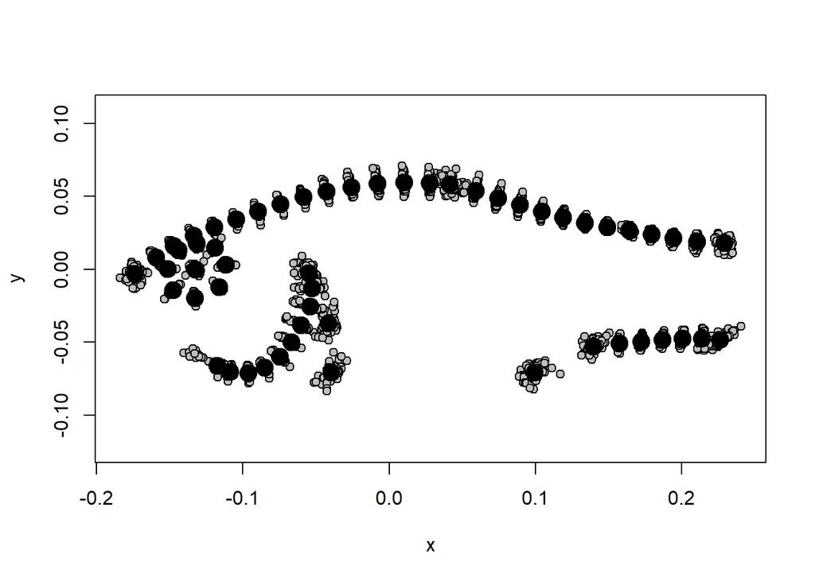

```r
data(pupfish)
Y.gpa <- gpagen(pupfish$coords, print.progress = FALSE)
plot(Y.gpa)
```

Now let’s evaluate covariation between head shape and body shape

```r
shape <- Y.gpa$coords
headland <- c(4, 10:17, 39:56)

PLS <- two.b.pls(shape[headland,,],shape[-headland,,], iter=999, print.progress = FALSE)
summary(PLS)
```

```
##
## Call:
## two.b.pls(A1 = shape[headland, , ], A2 = shape[-headland, , ],
##     iter = 999, print.progress = FALSE)
##
##
##
## r-PLS: 0.917
##
## Effect Size (Z): 5.4039
##
## P-value: 0.001
##
## Based on 1000 random permutations
```

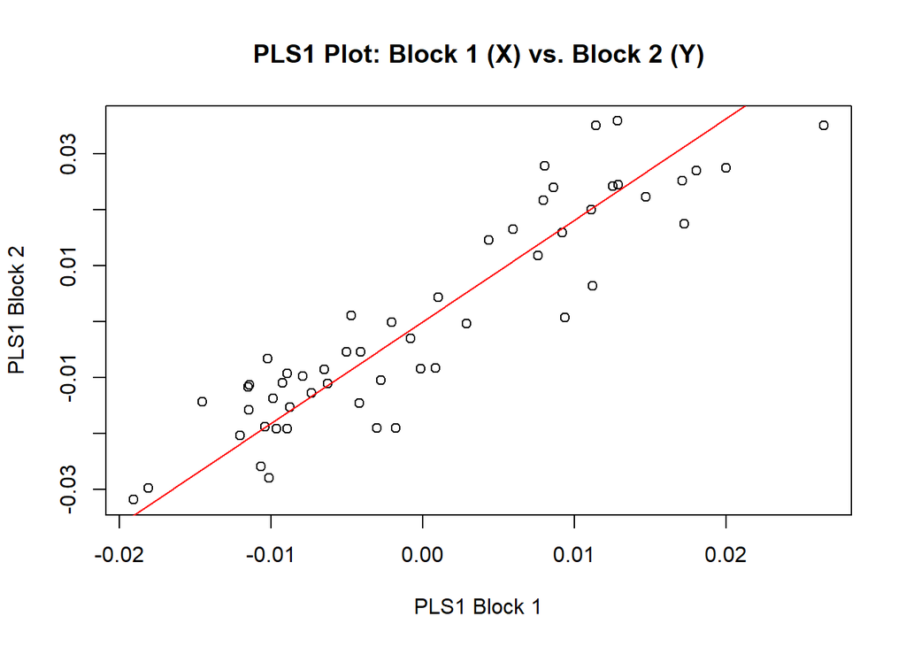

```r
plot(PLS)
```

The two are quite tightly associated. Finally, let’s visualize shape trends along this PLS axis. For this we use `shape.predictor`, as shown earlier for PCA and group mean predictions:

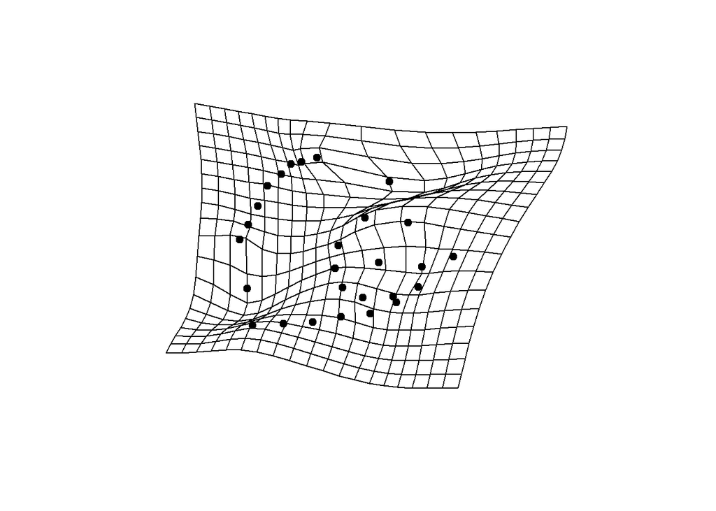

```r
preds <- shape.predictor(shape[headland,,], two.d.array(shape[-headland,,]), Intercept = FALSE,
                         method = "PLS", pred1 = -0.2, pred2 = 0.2) # using PLS plot as a guide

M <- mshape(shape[headland,,])
plotRefToTarget(M, -1*preds$pred1, mag=3)
```

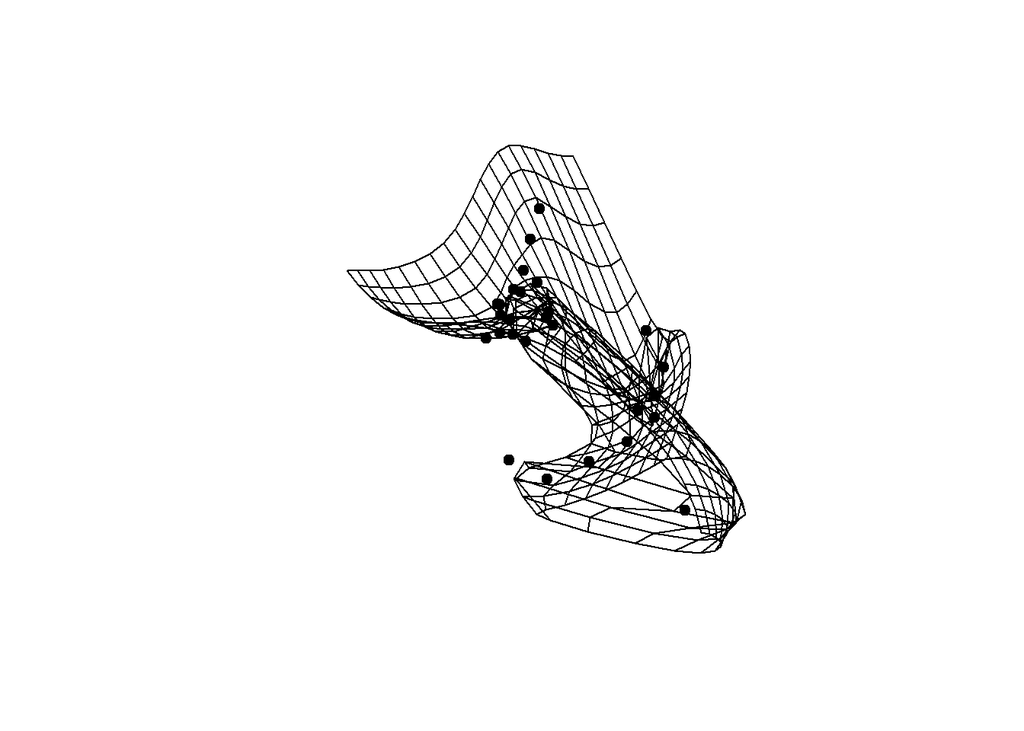

```r
plotRefToTarget(M, preds$pred2, mag=3)
```

These represent the changes in head shape across the PLS association axis (similar plots could be generated for body shape).

## **2: Regression**

The second analytical approach for evaluating multivariate associations is regression. In `geomorph`, regression is accomplished using `procD.lm`. This function has considerable options and flexibility, some of which are shown here (*MANY* others are demonstrated in the ANOVA lecture). Here we fit a regression of `shape~log(Csize)`.

```r
pupfish$logSize <- log(pupfish$CS)  #add logCS to geomorph data frame
fit <- procD.lm(coords ~ logSize, data = pupfish, print.progress = FALSE)
anova(fit)
```

```
##
## Analysis of Variance, using Residual Randomization
## Permutation procedure: Randomization of null model residuals
## Number of permutations: 1000
## Estimation method: Ordinary Least Squares
## Sums of Squares and Cross-products: Type I
## Effect sizes (Z) based on F distributions
##
##           Df       SS        MS     Rsq      F      Z Pr(>F)
## logSize    1 0.014019 0.0140193 0.24886 17.229 4.3462  0.001 **
## Residuals 52 0.042314 0.0008137 0.75114
## Total     53 0.056333
## ---
## Signif. codes:  0 '***' 0.001 '**' 0.01 '*' 0.05 '.' 0.1 ' ' 1
##
## Call: procD.lm(f1 = coords ~ logSize, data = pupfish, print.progress = FALSE)
```

For multivariate regression, we have several plotting options available. One contains diagnostic plots, which are useful in evaluating the robustness of the regression fit. The others are visualization plots: via predicted lines (Adams and Nistri 2010), and Regression Scores (Drake and Klingenberg 2008).

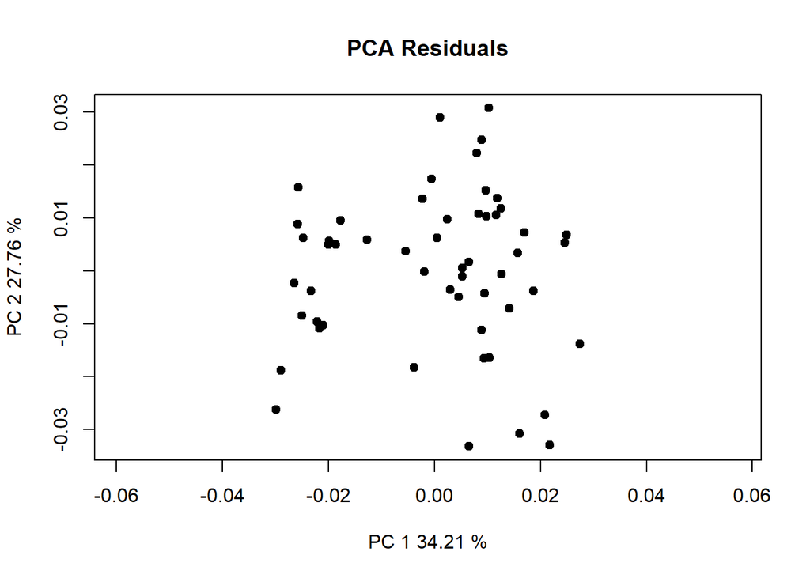

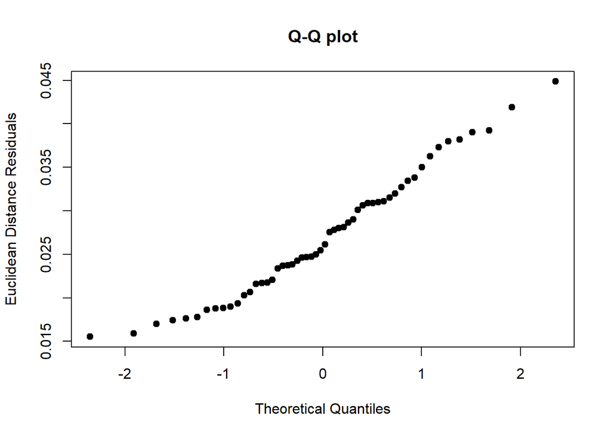

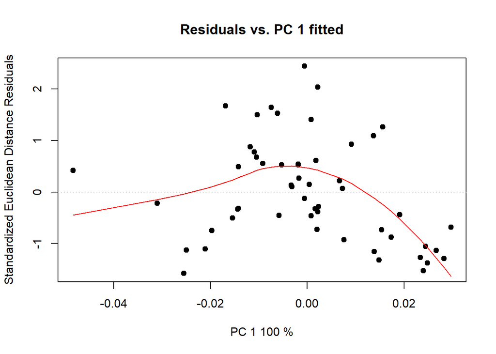

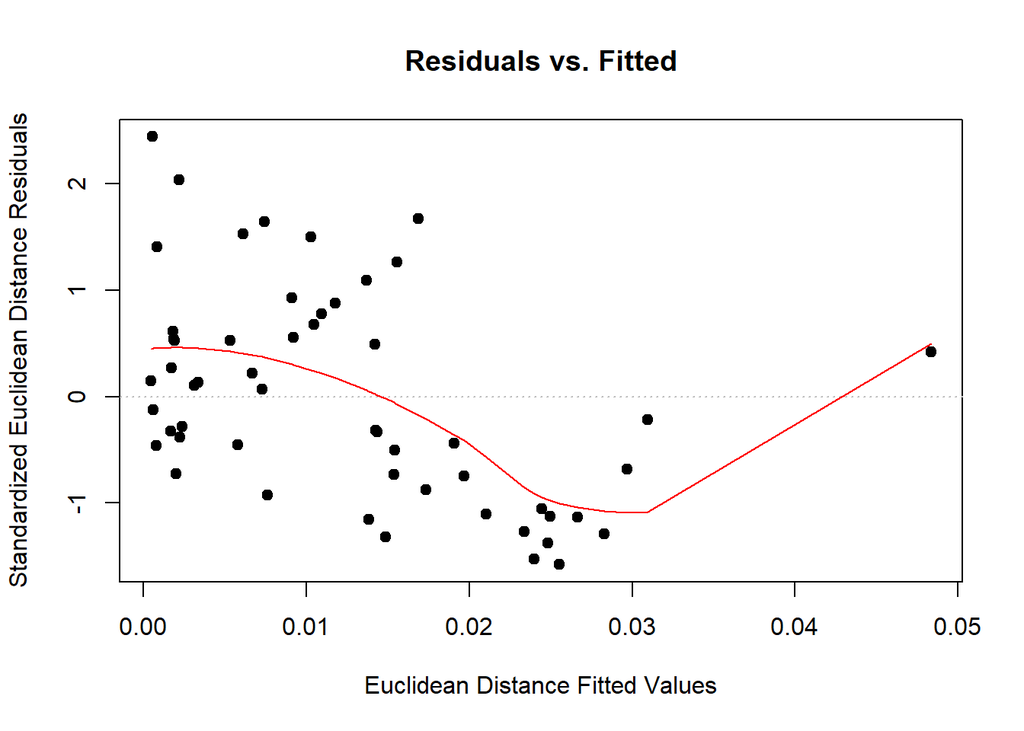

```r
plot(fit)
```

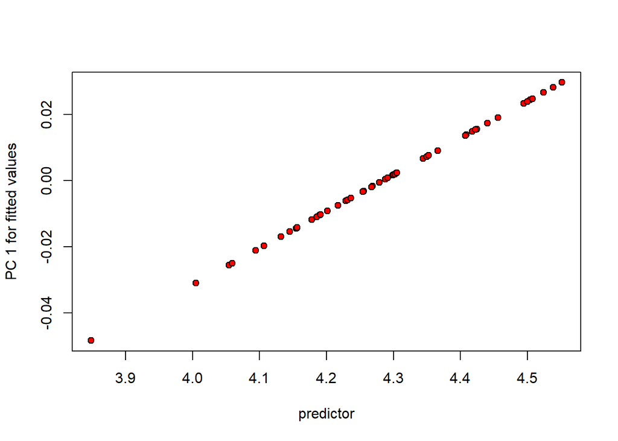

```r
plot(fit, type = "regression", reg.type = "PredLine", predictor = pupfish$logSize, pch=21, bg="red")
```

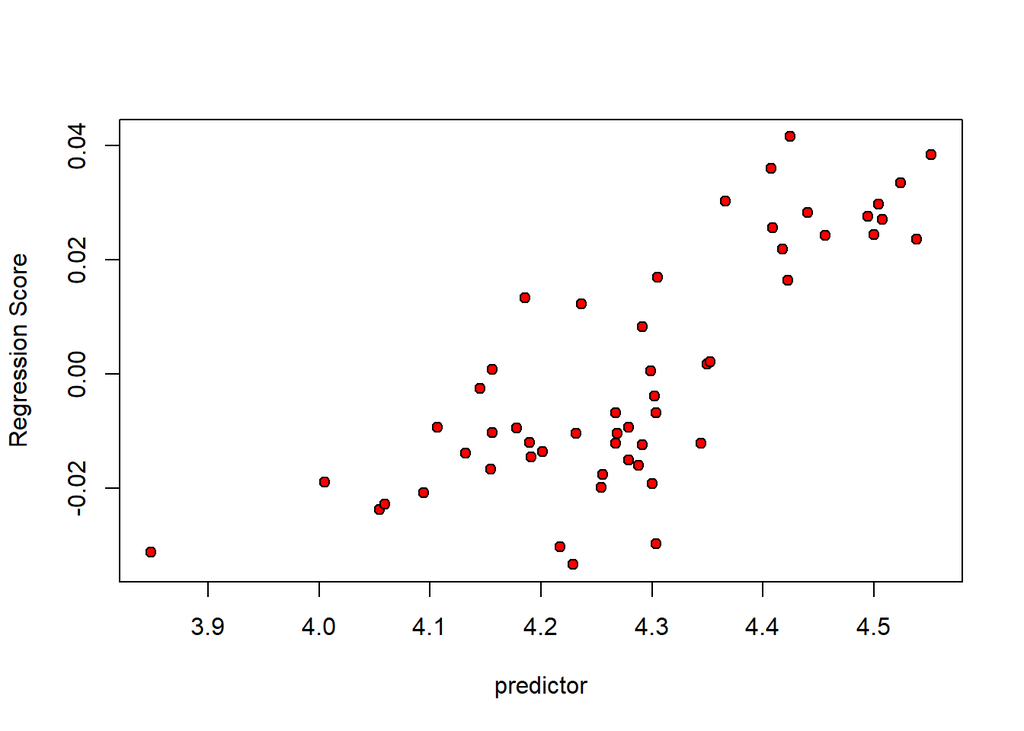

```r
plot(fit, type = "regression", reg.type = "RegScore", predictor = pupfish$logSize, pch=21, bg="red")
```

Finally, we can visualize shape changes along the regression using `shape.predictor`. These represent predicted shapes along the regression axis:

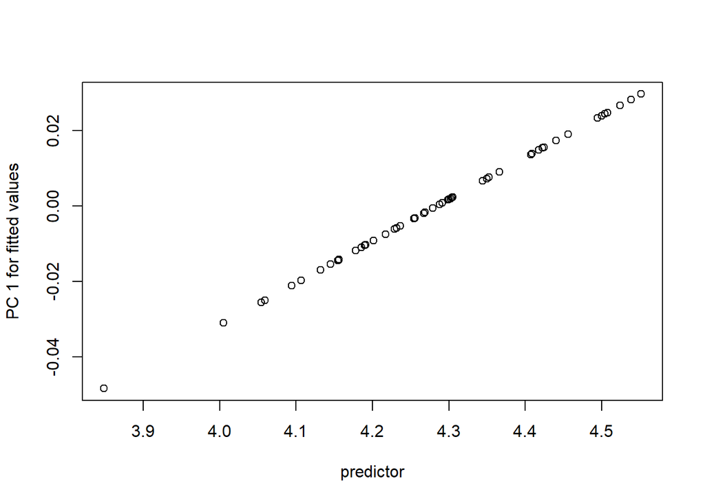

```r
allom.plot <- plot(fit,
                   type = "regression",
                   predictor = pupfish$logSize,
                   reg.type ="PredLine") # make sure to have a predictor
```

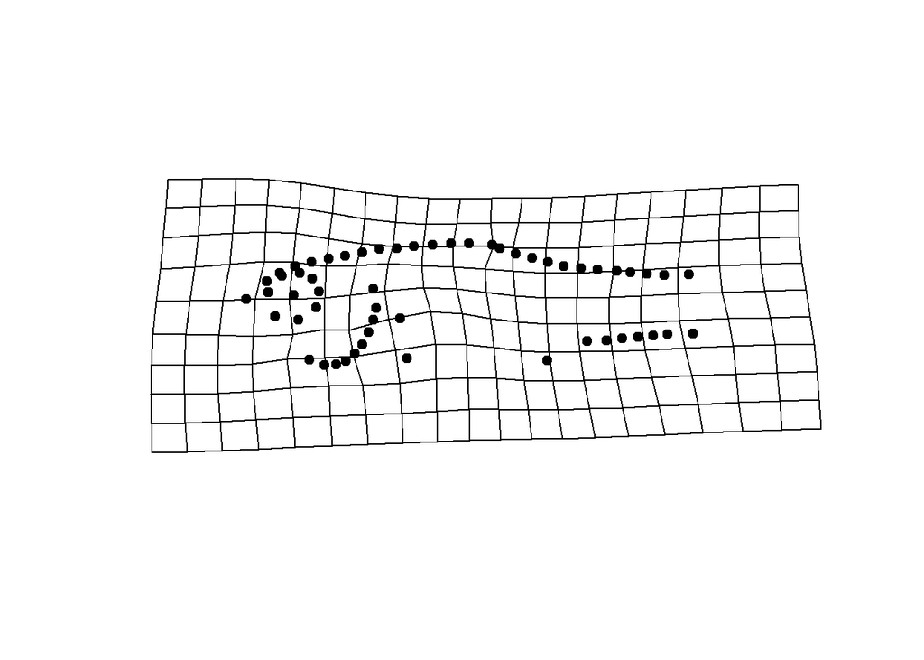

```r
preds <- shape.predictor(allom.plot$GM$fitted, x= allom.plot$RegScore, Intercept = FALSE,
                         predmin = min(allom.plot$RegScore),
                         predmax = max(allom.plot$RegScore))
M <- mshape(pupfish$coords)
plotRefToTarget(M, preds$predmin, mag=3)
```

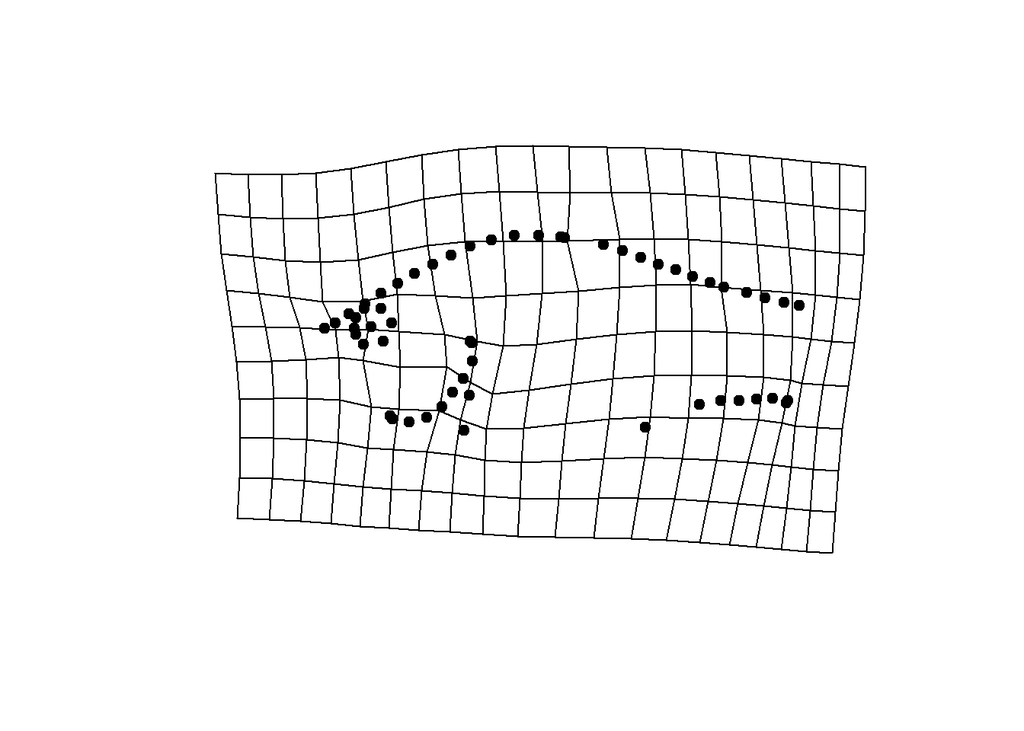

```r
plotRefToTarget(M, preds$predmax, mag=3)
```

### Notes

1. There is also a plot function, specifically for generating allometry plots, `plotAllometry`. It is no different than `procD.lm`, `type = "regression"` when the predictor is a size variable, but it might seem more intuitive for some users. For example:

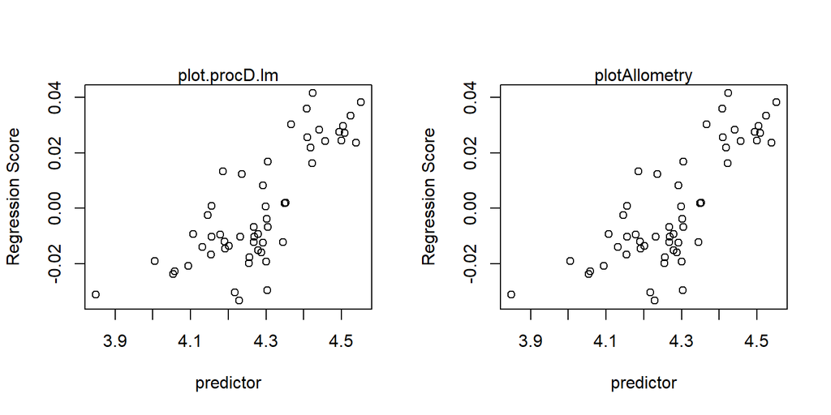

```r
par(mfcol = c(1,2))
plot(fit,
     type = "regression",
     predictor = pupfish$logSize,
     reg.type ="RegScore")

mtext("plot.procD.lm")

plotAllometry(fit,
              size = pupfish$CS,
              logsz = TRUE,
              method = "RegScore")
mtext("plotAllometry")
```

2. The `picknplot.shape` function allows interactive shape prediction in any of the plots generated here. As it is interactive, one would have to run the script associated with this lab tutorial to get a feel for how it works.